# Advanced-Statistics-With-R

## 4.3 Multiple R

- Multiple R squared is reported in summary(lm).
- Multiple R is the multiple-regression analogue of the Pearson product moment correlation coefficient r.
- The correlation between predicted percent value and the actual value.
- If the multiple R is squared, it measures how much of the variation in the actual depression score is accounted for by knowing the information included in the regression equation.

## 4.4 Selecting Variables for Regression Models

- Deciding on the variables that provide the best prediction is a process sometimes referred to as *model building*.
- *Forward selection*: Begins with one variable in the regression equation; then, additional variables are added one at a time until all statistically significant variables are included in the equation. The first variable in the regression equation is the X variable that has the highest correlation with the response variable y. The next X variable considered for the regression equation is the one that increases R-squared by the largest amount. If the increment in R-squared is statistically significant by the F test, it is included in the regression equation. This step-by-step procedure continues until no X variables remain that produce a significant increase in R-squared.
- *Backward elimination*: All variables are initially included in the regression equation. The X variable that would reduce R-squared by the smallest increment is removed from the equation. If the resulting decrease is not statistically significant, that variable is permanently removed from the equation.
- When features of both the forward selection and the backward elimination procedures are used together, the method is called *stepwise regression* (stepwise selection).
- Variables are sometimes grouped according to their function, such as all demographic characteristics, and added to the regression equation as a group or block; this process is often called *hierarchical regression*.

## 4.5 Polynomial Regression

- The formula:

$y=b_0+b_1X+b_2X^2+....b_nX^n$

- Example:

```r
# Load the data
head(Fat_data,3)
```

|  | Participant | BMI | Percent.Fat | Sex | Age |
| --- | --- | --- | --- | --- | --- |
| 1 | 1 | 30.7 | 33.6 | F | 23.2 |
| 2 | 2 | 23.0 | 26.6 | F | 20.9 |
| 3 | 3 | 20.0 | 25.9 | F | 21.0 |

```r
# Examine the poly function.
head(poly(Fat_data$BMI,degree = 2,raw = TRUE),6)
```

```
##         1      2
## [1,] 30.7 942.49
## [2,] 23.0 529.00
## [3,] 20.0 400.00
## [4,] 23.2 538.24
## [5,] 20.8 432.64
## [6,] 26.6 707.56
```

```r
# Fit the linear model
regressor<-lm(data = Fat_data,
              formula = Percent.Fat~poly(BMI, degree = 2, raw = TRUE))
summary(regressor)
```

```
##
## Call:
## lm(formula = Percent.Fat ~ poly(BMI, degree = 2, raw = TRUE),
##     data = Fat_data)
##
## Residuals:
##     Min      1Q  Median      3Q     Max
## -20.479  -3.645   1.302   5.426  13.765
##
## Coefficients:
##                                    Estimate Std. Error t value Pr(>|t|)
## (Intercept)                        41.77320   22.13195   1.887   0.0618 .
## poly(BMI, degree = 2, raw = TRUE)1 -1.95691    1.74073  -1.124   0.2634
## poly(BMI, degree = 2, raw = TRUE)2  0.05708    0.03367   1.695   0.0930 .
## ---
## Signif. codes:  0 '***' 0.001 '**' 0.01 '*' 0.05 '.' 0.1 ' ' 1
##
## Residual standard error: 7.914 on 108 degrees of freedom
## Multiple R-squared:  0.1986, Adjusted R-squared:  0.1838
## F-statistic: 13.39 on 2 and 108 DF,  p-value: 6.408e-06
```

## 4.6 Cross Validation

- If the equation is to be used to predict outcomes for future subject, it should, therefore, be validated on a second sample, a process *called cross validation*.
- The regression equation is used to predict the outcome in the second sample, and the predicted outcomes are compared with the actual outcomes; the correlation between the predicted and actual values indicates how well the model fits.
- Researchers can hold out a proportion of the subjects for cross validation, perhaps 20% or 25%. The holdout sample should be randomly selected from the entire sample prior to the original analysis. The predicted outcomes in the holdout sample are compared with the actual outcomes, often using R-squared to judge how well the findings cross-validate.
- Another method is the *jackknife* in which one observation is left out of the sample, call it x1; regression is performed using the n - 1 observations, and the results are applied to x1. Then this observation is returned to the sample, and another, x2 is held out. This process continues until there is a predicted outcome for each observation in the sample; the predicted and actual outcomes are then compared.
- The *bootstrap* method works in a similar manner, although the goal is different. The bootstrap can be used with small samples to estimate the standard error and confidence intervals.

# 5 Controlling For Cofounding

## 5.1 Analysis of Covariance

- For further reading please refer to: https://www.r-bloggers.com/2021/10/analysis-of-covariance-ancova-using-r/
- Analysis of covariance (ANCOVA) is the statistical technique used to control for the influence of a confounding variable. Confounding variables occur most often when subjects cannot be assigned at random to different groups, that is, when the groups of interest already exist.
- ANCOVA is a general linear model which blends ANOVA and regression. ANCOVA requires at least one continuous and one categorical independent variable known as treatment. *Covariate* is an additional continuous independent variable in ANCOVA (also known as co-founding variable, contaminant). By statistically modifying the influence of covariate, ANCOVA evaluates differences between groups in a categorical independent variable. ANCOV basically removes the variance associated with covariate.
- Mathematically, ANCOVA decomposes the variance in the dependent variable into variance explained by the covariates, variance explained by the categorical independent variables, and residual variance.
- In ANCOVA, the adjusted Y mean for a given group (j) is obtained by:

$Adjusted\ \overline{y_j}=Unadjusted\ \overline{y_j}+b(\overline{X_j}-\overline{X})$

$\overline{X}= \text{global mean of covariate}$

- Useful methods to control for confounding variables are analysis of covariance *(ANCOVA) and the Mantel-Haenszel chi-square procedure*. It is appropriate to use ANCOVA when the *dependent variable is numerical* and the independent measures are grouping variables on a nominal scale (e.g., smoking vs. nonsmoking), and confounding variables occur.
- If the *dependent measure is also nominal*, such as whether a patient has survived to a given time, *the Mantd-Haenszel chi-square* can be used to control for the effect of a confounding variable.
- Linear model formula for ANCOVA:

$y=b_0+b_1X+b_2Z+b_3XZ$

- The regression lines have equal slopes and are parallel when b3 is 0, that is, no interaction between the independent variable X and Z.
- The regression lines have equal intercepts and equal slopes (are coincident) if both b2 and b3 are O.
- *Assumptions of ANCOVA*
1. Independence of observations.
2. Normality and homogeneity of variances.
3. Linearity assumption: At each level of categorical independent variable, the covariate should be linearly related to the dependent variable. If the relationship is no linear, the adjustment made to covariate will be biased.
4. Homogeneity of within-groups regression slopes (parallelism or non interaction). There should be no interaction between categorical independent variable and covariate. The regression lines between the covariate and dependent variable for each group of independent variable should be parallel. (same slope)
5. Dependent variable and covariate should be measured in continuous scale.
6. Covariate should be measured without error or little error as possible.

```r
# ANCOVA Example
# Question: Is there a difference in %Body-Fat of Man and Woman.
# BMI is a co-founding factor in this example.

# Loading data
head(Fat_data,5)
```

|  | Participant | BMI | Percent.Fat | Sex | Age |
| --- | --- | --- | --- | --- | --- |
| 1 | 1 | 30.7 | 33.6 | F | 23.2 |
| 2 | 2 | 23.0 | 26.6 | F | 20.9 |
| 3 | 3 | 20.0 | 25.9 | F | 21.0 |
| 4 | 4 | 23.2 | 40.6 | F | 20.9 |
| 5 | 5 | 20.8 | 30.0 | F | 22.1 |

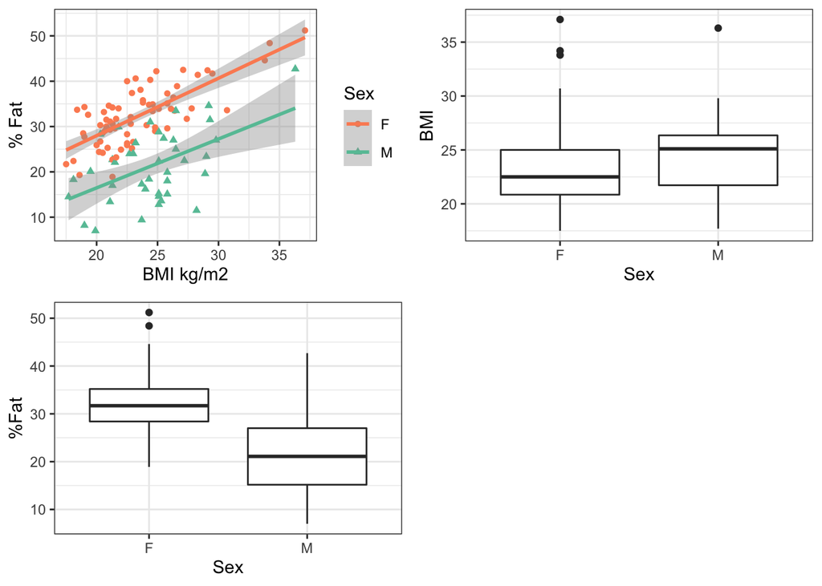

```r
# Visualization
regplot<-ggplot(data=Fat_data,
                aes(x=BMI, y=Percent.Fat, shape=Sex, color=Sex ))+
  geom_point()+
  scale_color_brewer(palette="Set2",direction = -1)+
  xlab("BMI kg/m2")+
  ylab("% Fat")+
  theme_bw()+
  stat_smooth(formula=y~x, method = "lm", se=TRUE)
boxplt1<-ggplot(data = Fat_data,
               aes(x=Sex, y=BMI))+
  geom_boxplot()+
  theme_bw()
boxplt2<-ggplot(data = Fat_data,
               aes(x=Sex, y=Percent.Fat))+
  geom_boxplot()+
  theme_bw()+
  labs(y="%Fat")
ggarrange(regplot, boxplt1, boxplt2)
```

```r
# Linearity assumption is satisfied.
# Regression lines for F and M patients looks parallel.

# Performing One Way ANCOVA
ANCOVA<-anova_test(data = Fat_data[,2:4],
                   formula = Percent.Fat~BMI+Sex,
                   type = 3,# Type 3 Sums of Squares should be used in ANCOVA
                   detailed = TRUE, covariate = BMI)
ANCOVA
```

|  | Effect | SSn | SSd | DFn | DFd | F | p | p<.05 | ges |
| --- | --- | --- | --- | --- | --- | --- | --- | --- | --- |
| 1 | (Intercept) | 10.403 | 3157.434 | 1 | 108 | 0.356 | 5.52e-01 |  | 0.003 |
| 2 | BMI | 2231.282 | 3157.434 | 1 | 108 | 76.321 | 3.42e-14 | * | 0.414 |
| 3 | Sex | 3786.361 | 3157.434 | 1 | 108 | 129.512 | 3.39e-20 | * | 0.545 |

```r
# ANCOVA results indicate:
# There is significant difference in mean %Fat [F(1,108)= 129.512, p<0.001]
# between F and M subjects whilst adjusting the effect of BMI.
# The covariate BMI is significant suggesting:
# It is an important predictor for %Fat.

# Get Adjusted Means(Estimated Marginal Means)
adj_means<-rstatix::emmeans_test(data = Fat_data[,2:4],
                                 formula = Percent.Fat~Sex,
                                 covariate = BMI,
                                 p.adjust.method="bonferroni")
rstatix::get_emmeans(adj_means)
```

| BMI | Sex | emmean | se | df | conf.low | conf.high | method |
| --- | --- | --- | --- | --- | --- | --- | --- |
| 23.8036 | F | 32.77429 | 0.6441921 | 108 | 31.49739 | 34.05119 | Emmeans test |
| 23.8036 | M | 20.47814 | 0.8608249 | 108 | 18.77183 | 22.18444 | Emmeans test |

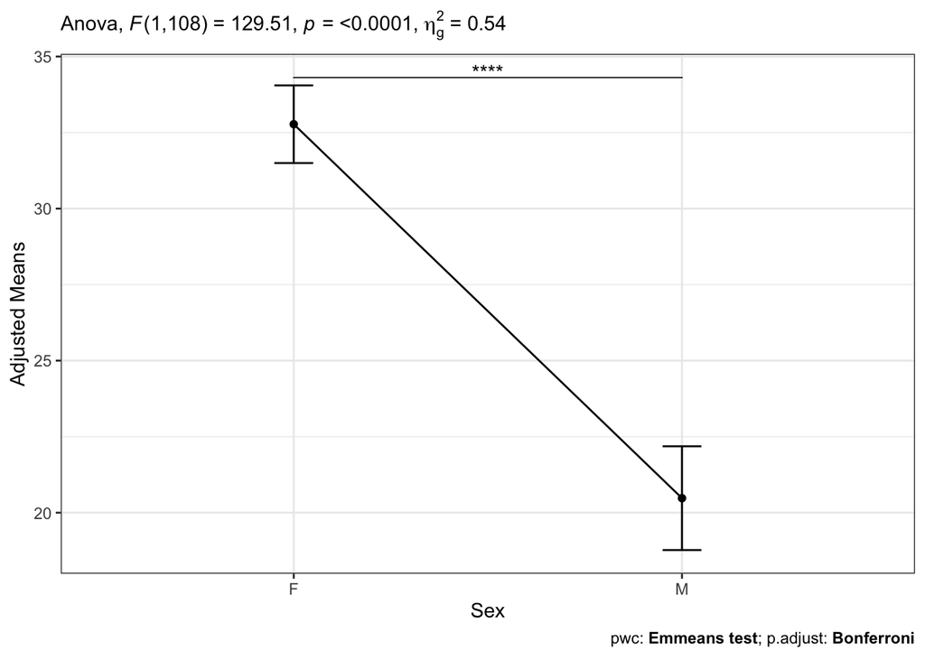

```r
# emmeans gives estimated marginal means, also known as least-square means
# EMMS are adjusted for each treatment or category.
# F subjects has higher percent body fat whilst controlling effect of BMI.

# ==Visualization==

adj_means<-adj_means %>% add_xy_position(x="Sex", fun = "mean_se")
ggplot(data=get_emmeans(adj_means), aes(x=Sex, y=emmean, group=1))+
  # For line graphs, the data points must be grouped.
  # So that line graph knows which points to connect.
  # In this case all points need to connected. So group=1
  geom_line()+
  geom_point()+
  geom_errorbar(aes(ymin=conf.low, ymax=conf.high), width=.1)+
  stat_pvalue_manual(data = adj_means, hide.ns = TRUE, tip.length = FALSE)+
  labs(y="Adjusted Means",
       subtitle=get_test_label(ANCOVA, detailed = TRUE),
       caption = get_pwc_label(adj_means))+
  theme_bw()
```

```r
# ==Testing ANCOVA Assumptions==
#
# Assumption of Normality:
# The residuals should be approximately normally distributed.
shapiro.test(resid(aov(Percent.Fat ~ BMI+Sex, data = Fat_data[,2:4])))
```

```
##
##  Shapiro-Wilk normality test
##
## data:  resid(aov(Percent.Fat ~ BMI + Sex, data = Fat_data[, 2:4]))
## W = 0.99231, p-value = 0.7936
```

```r
# As the p-value is non-significant (p > 0.05),
# we fail to reject the null hypothesis and conclude that -->
# data is drawn from a normal distribution.
# In addition,
# QQ plots and histograms can be used to assess the assumptions of normality.
# plot(aov(Percent.Fat ~ BMI+Sex, data = Fat_data[,2:4]))
# If the sample size is sufficiently large (n > 30) -->
# the moderate departure from normality can be allowed.

# Assumptions of homogeneity of variances:
# The variance should be similar for all categorical variables.
# Bartlett’s test can be used to check the homogeneity of variances.
# Null hypothesis: samples from populations have equal variances.
bartlett.test(Percent.Fat ~ Sex, data = Fat_data[,2:4])
```

```
##
##  Bartlett test of homogeneity of variances
##
## data:  Percent.Fat by Sex
## Bartlett's K-squared = 1.6822, df = 1, p-value = 0.1946
```

```r
# As the p-value is non-significant (p > 0.05),
# We fail to reject the null hypothesis and conclude that-->
# sexes have equal variances.

# Assumptions of homogeneity of regression slopes (covariate coefficients):
# This is an important assumption in ANCOVA.
# There should be no interaction between -->
# the categorical independent variable and covariate.
# This can be tested using-->
# interaction terms between Sex and BMI in ANOVA.
Anova(aov(Percent.Fat ~ BMI*Sex, data = Fat_data[,2:4]), type=3)
```

|  | Sum Sq | Df | F value | Pr(>F) |
| --- | --- | --- | --- | --- |
| (Intercept) | 12.58120 | 1 | 0.4280259 | 5.143629e-01 |
| BMI | 1625.36957 | 1 | 55.2968099 | 2.710730e-11 |
| Sex | 35.11161 | 1 | 1.1945344 | 2.768714e-01 |
| BMI:Sex | 12.32452 | 1 | 0.4192933 | 5.186768e-01 |
| Residuals | 3145.10990 | 107 | NA | NA |

```r
# As the p value is for interaction is non-significant (p > 0.05)
# there is no interaction between BMI and Sex.
```

# 6 Predicting Nominal Outcomes

## 6.1 Logistic Regression

- Many outcomes in health are nominal, actually binary, variables-they either occur or do not occur.
- Regression coefficients obtained in logistic regression can be transformed into odds ratios.
- Logistic regression provides a way to obtain an odds ratio for a given risk factor that controls for, or is adjusted for, confounding variables; in other words, we can do analysis of covariance with logistic regression as well as with multiple linear regression.
- Logistic regression is commonly used when the independent variables include both numerical and nominal measures and the *outcome variable is binary*.
- The logistic model gives the probability that the outcome, occurs as an exponential function of the independent variables.
- The model is:

$P_X=\dfrac{1}{1+exp[-(b_0+b_1X_1+b_2X_2+b_3X_3)]}$

$exp=\text{the base of the natural logarithm (2.718) is taken to the power shown in parentheses}$

- In logistic regression model response variable is log odds:

$ln(odds)=ln(\dfrac{p}{1-p})=b_0+b_1X_1+b_2X_2$

- Regression coefficient can be interpreted in terms of relative risks in cohort studies or odds ratios in case-control studies.
- One advantage of logistic regression is that it requires no assumptions about the distribution of the independent variables.
- A chisquare test (instead of the tor F test) is used to determine whether a variable adds significantly to the prediction.
- The logistic equation can be used to find the probability for any given individual.
- The overall results from a logistic regression may be tested with *Hosmer and Lemeshow’s goodness of fit test*. The test is based on the chi-square distribution. A p value ,0.05 means that the model’s estimates fit the data at an acceptable level.
- Logistic Regression Example:
- Data set Explanation: use of logistic regression to identify patients that may experience an extended length of stay in the hospital (> 7 days) based on clinical indications. Shah and his co investigators (2018) wanted to develop a model to help hospital staff predict which patients with pulmonary hypertension may experience long postoperative stays in the hospital.

```r
# ==Logistic Regression example==
# Loading data
dataset<-data.frame(
  readxl::read_xlsx("Pulmonary_ht.xlsx"))[,c("ASA..3..3",
                                             "POOR.Functional.Status",
                                             "NO.sHTN",
                                             "OPEN.Surgical.Approach",
                                             "Proc.Length...2..2",
                                             "SEVERE.PHTN",
                                             "CORRECT.LOS...7..7")]
colnames(dataset)<-c("ASA","Poor Functional Status",
                     " No sHTN", "Open Surgical Approach",
                     "Procedure Lenght", "Severe PHTN", "Correct.LOS")
# Removing incomplete observations
dataset<-dataset[complete.cases(dataset),]
# Each variable has 524 observations.
# Numerical coding-->
# ASA = 1 : ASA>3.
# Procedure Length = 1 : Procedure Length>2hours
# No sHTN = 1 : No Severe Hypertension
# Correct LOS = 1 : Correct Lenght Of Stay > 7 days
# For all other predictor variables 1= yes , 0=no
head(dataset)
```

|  | ASA | Poor Functional Status | No sHTN | Open Surgical Approach | Procedure Lenght | Severe PHTN | Correct.LOS |
| --- | --- | --- | --- | --- | --- | --- | --- |
| 1 | 0 | 1 | 0 | 1 | 0 | 0 | 0 |
| 2 | 0 | 0 | 1 | 0 | 0 | 0 | 0 |
| 3 | 0 | 0 | 0 | 0 | 0 | 0 | 0 |
| 4 | 0 | 1 | 1 | 0 | 0 | 0 | 1 |
| 5 | 0 | 0 | 0 | 0 | 1 | 0 | 0 |
| 6 | 0 | 0 | 0 | 0 | 1 | 0 | 0 |

```r
# Fitting Logistic Regression to the data set
logistic_model<-glm(formula = Correct.LOS~.,
                data = dataset,
                family = "binomial")
summary(logistic_model)
```

```
##
## Call:
## glm(formula = Correct.LOS ~ ., family = "binomial", data = dataset)
##
## Deviance Residuals:
##     Min       1Q   Median       3Q      Max
## -1.6448  -0.6602  -0.4643  -0.2701   2.3335
##
## Coefficients:
##                          Estimate Std. Error z value Pr(>|z|)
## (Intercept)              -3.29264    0.31409 -10.483  < 2e-16 ***
## ASA                       0.90522    0.24957   3.627 0.000287 ***
## `Poor Functional Status`  0.76080    0.23996   3.171 0.001522 **
## ` No sHTN`                0.63795    0.24134   2.643 0.008210 **
## `Open Surgical Approach`  1.11930    0.25342   4.417 1.00e-05 ***
## `Procedure Lenght`        0.92300    0.23501   3.927 8.58e-05 ***
## `Severe PHTN`            -0.07177    0.39205  -0.183 0.854740
## ---
## Signif. codes:  0 '***' 0.001 '**' 0.01 '*' 0.05 '.' 0.1 ' ' 1
##
## (Dispersion parameter for binomial family taken to be 1)
##
##     Null deviance: 546.37  on 523  degrees of freedom
## Residual deviance: 468.67  on 517  degrees of freedom
## AIC: 482.67
##
## Number of Fisher Scoring iterations: 5
```

```r
confint(logistic_model)
```

```
##                               2.5 %     97.5 %
## (Intercept)              -3.9378929 -2.7042143
## ASA                       0.4144337  1.3947381
## `Poor Functional Status`  0.2955211  1.2382497
## ` No sHTN`                0.1644022  1.1124931
## `Open Surgical Approach`  0.6325849  1.6288709
## `Procedure Lenght`        0.4643965  1.3873739
## `Severe PHTN`            -0.8734590  0.6729203
```

```r
# Interpreting Results
# Severe PHTN is not statistically significant.
# Severe PHTN p>0.05, confidence interval of coefficients include 0
# Since logistic regression model response variable is log odds -->
# Having Open Surgical Procedure increases log odds by 1.12,
# Poor Functional Status increases log odds by 0.76.
# The relative risk of a LOS > 7 after a surgical procedure over 2 hours is:
# exp(0.923) = 2.5.
# The relative risk for a short procedure is the reciprocal,
# 1/2.5= 0.4
# Therefore, patients undergoing a procedure over 2 hours in duration are-->
# more than two times more likely to have a long length of stay as those
# having shorter duration procedures.
# Other relative risk estimates can be obtained using below code:
exp(coef(logistic_model))
```

```
##              (Intercept)                      ASA `Poor Functional Status`
##               0.03715551               2.47248752               2.13998612
##               ` No sHTN` `Open Surgical Approach`       `Procedure Lenght`
##               1.89259423               3.06271373               2.51681751
##            `Severe PHTN`
##               0.93074161
```

```r
exp(confint(logistic_model))
```

```
##                               2.5 %     97.5 %
## (Intercept)              0.01948924 0.06692288
## ASA                      1.51351340 4.03391785
## `Poor Functional Status` 1.34382647 3.44957029
## ` No sHTN`               1.17868825 3.04193268
## `Open Surgical Approach` 1.88247039 5.09811500
## `Procedure Lenght`       1.59105369 4.00432033
## `Severe PHTN`            0.41750489 1.95995253
```

```r
# To prevent over fitting remove Severe PHTN.
logistic_model<-glm(formula = Correct.LOS~.,
                data = dataset[-6],
                family = "binomial")
summary(logistic_model)
```

```
##
## Call:
## glm(formula = Correct.LOS ~ ., family = "binomial", data = dataset[-6])
##
## Deviance Residuals:
##     Min       1Q   Median       3Q      Max
## -1.6390  -0.6584  -0.4634  -0.2696   2.3350
##
## Coefficients:
##                          Estimate Std. Error z value Pr(>|z|)
## (Intercept)               -3.2966     0.3134 -10.520  < 2e-16 ***
## ASA                        0.8962     0.2447   3.663 0.000249 ***
## `Poor Functional Status`   0.7586     0.2397   3.165 0.001550 **
## ` No sHTN`                 0.6382     0.2413   2.645 0.008176 **
## `Open Surgical Approach`   1.1196     0.2534   4.418 9.98e-06 ***
## `Procedure Lenght`         0.9247     0.2348   3.938 8.21e-05 ***
## ---
## Signif. codes:  0 '***' 0.001 '**' 0.01 '*' 0.05 '.' 0.1 ' ' 1
##
## (Dispersion parameter for binomial family taken to be 1)
##
##     Null deviance: 546.37  on 523  degrees of freedom
## Residual deviance: 468.70  on 518  degrees of freedom
## AIC: 480.7
##
## Number of Fisher Scoring iterations: 5
```

```r
# Predicting values
# The probability that a patient with an:
# ASA of 1, poor functional status, No sHTN,
# and a 1-hour open surgical procedure -->
# has a length of stay longer than 7 days
test_set=data.frame(0,1,1,1,0,1)
colnames(test_set)<-colnames(dataset[,-7])
predict(logistic_model, type = 'response', newdata = test_set)
```

```
##         1
## 0.3142574
```

```r
# Predicting the results of actual data set
# NOTE: It is recommended to create a independent test set and evaluate model
prob_pred = predict(logistic_model, type = 'response', newdata = dataset[-7])
y_pred = ifelse(prob_pred > 0.5, 1, 0)

# Making the Confusion Matrix
cm = table(dataset[,7], y_pred > 0.5)
dimnames(cm)<-list("Observed"=c("Correct LOS≤7","Correct LOS>7"),
                   "Predicted"=c("Correct LOS≤7","Correct LOS>7"))
# Assessing model accuracy
mean(y_pred==dataset[7])
```

```
## [1] 0.7938931
```

```r
# Checking goodness of fit of the model with:
# Hosmer and Lemeshow's goodness of fit test
# There are several packages to perfor HL GOF test
# ResourceeSelection  package --> hoslem.test
# oerformance package --> performance_hosmer
# largesamplehl package --> hltest
ResourceSelection::hoslem.test(x=logistic_model$y,
                               y=fitted(logistic_model),
                               g = 10)
```

```
##
##  Hosmer and Lemeshow goodness of fit (GOF) test
##
## data:  logistic_model$y, fitted(logistic_model)
## X-squared = 2.2506, df = 8, p-value = 0.9723
```

```r
performance::performance_hosmer(logistic_model,n_bins=10)
```

```
## # Hosmer-Lemeshow Goodness-of-Fit Test
##
##   Chi-squared: 2.251
##            df: 8
##       p-value: 0.972
```

```r
# The results of the HL GOF tests indicate:
# Logistic regression is a good fit to the observed data(p>0.05)

# Kappa statistics for agreement between logistic model and real observations
psych::cohen.kappa(cm)
```

```
## Call: cohen.kappa1(x = x, w = w, n.obs = n.obs, alpha = alpha, levels = levels)
##
## Cohen Kappa and Weighted Kappa correlation coefficients and confidence boundaries
##                  lower estimate upper
## unweighted kappa  0.13     0.23  0.32
## weighted kappa    0.13     0.23  0.32
##
##  Number of subjects = 524
```

```r
vcd::Kappa(cm)
```

```
##             value     ASE     z  Pr(>|z|)
## Unweighted 0.2271 0.04945 4.592 4.393e-06
## Weighted   0.2271 0.04945 4.592 4.393e-06
```

```r
# There is minimal agreement between logistic model and real observations
```

## 6.2 Log Linear Analysis

- *Log linear analysis* can be used when each independent variable in a research problem is measured on a *categorical or nominal scale* (age, onset, and familial status), as is the outcome variable (occurrence of symptom etc.).
- If *only two variables are being analyzed*, the *chi-square* method introduced can be used to determine whether a relationship exists between them; with *three or more nominal or categorical variables*, a statistical method called log-linear analysis is appropriate. Log-linear analysis is analogous to a regression model in which *all the variables, both independent and dependent, are measured on a nominal scale*. The technique is called log-linear because it involves using the logarithm of the observed frequencies in the contingency table.
- Log linear models model cell counts in contingency tables. Log linear models do not distinguish between response and explanatory variables. All variables in log linear model are essentially “response”. That’s why log linear analysis may also be used to analyze multidimensional contingency tables in situations in which no distinction exists between independent and dependent variables, that is, when investigators simply want to examine the *relationship among a set of nominal measures*.
- For a contingency table: Cell count in a row *i* and column *j* is equal to the product of the marginal probabilities and the number of observations. This can be expressed as:

$\mu_{ij}=n\pi_i\pi_j$

- If we take the log of each side it becomes additive (linear). Below equation displays log linear model of independence for two-way contingency table.

$log\mu_{ij}=logn+log\pi_i+log\pi_j$

- If these two variables are not independent, this model does not work well. In that case additional parameter for interaction could be added to the model.
- Below example researchers are interested in how cell counts in contingency table depend on the levels of the categorical variable. Important Note: If researchers were interested in modeling a categorical variable (marijuana use in the below example) as a function of other two variables, then they would use logistic regression. But they were interested in *understanding the relationship between all three variables* without one necessarily being the response variable (Log linear model).

```r
# Data preparation
# Substance use amongs students
# Creating a contingency table to analyze
# array function enables creation of tables with more than 2 dimensions
seniors <- array(data = c(911, 44, 538, 456, 3, 2, 43, 279),
                         dim = c(2,2,2),# 2 rows 2 columns and 2 layers
                         dimnames = list("cigarette" = c("yes","no"), # rows
                                         "marijuana" = c("yes","no"), #columns
                                         "alcohol" = c("yes","no")))  # layers
# Printing object will return it as 2x2 table
# Flat contingency table with ftable function
ftable(seniors, row.vars = c("alcohol","cigarette"))
```

```
##                   marijuana yes  no
## alcohol cigarette
## yes     yes                 911 538
##         no                   44 456
## no      yes                   3  43
##         no                    2 279
```

```r
# Explore marginal totals
addmargins(seniors)
```

```
## , , alcohol = yes
##
##          marijuana
## cigarette yes  no  Sum
##       yes 911 538 1449
##       no   44 456  500
##       Sum 955 994 1949
##
## , , alcohol = no
##
##          marijuana
## cigarette yes  no Sum
##       yes   3  43  46
##       no    2 279 281
##       Sum   5 322 327
##
## , , alcohol = Sum
##
##          marijuana
## cigarette yes   no  Sum
##       yes 914  581 1495
##       no   46  735  781
##       Sum 960 1316 2276
```

```r
# Calculating proportions
# Overall proportions using flattened table
ftable(seniors, row.vars = c("alcohol","cigarette"))%>%prop.table()
```

```
##                   marijuana          yes           no
## alcohol cigarette
## yes     yes                 0.4002636204 0.2363796134
##         no                  0.0193321617 0.2003514938
## no      yes                 0.0013181019 0.0188927944
##         no                  0.0008787346 0.1225834798
```

```r
# Proportions across the columns along the rows for each layer -->
# margin c(1,3) : 1--> rows, 3--> layers
# also can be written as margin = c("cigarette","alcohol")
prop.table(seniors, margin = c(1,3))
```

```
## , , alcohol = yes
##
##          marijuana
## cigarette       yes        no
##       yes 0.6287095 0.3712905
##       no  0.0880000 0.9120000
##
## , , alcohol = no
##
##          marijuana
## cigarette         yes        no
##       yes 0.065217391 0.9347826
##       no  0.007117438 0.9928826
```

```r
# %62 of students who tried cigarette and alcohol also tried marijuana.
# %99 of students who did not tried alcohol/cigaratte do not tried marijuana.

# Transform flattened table format to data frame to work with glm function.
# Fist convert the array to table format to be able to convert it df later.
seniors.df<-as.data.frame(as.table(seniors))
# Additional step to set the reference level of 3 variables to "no".
# In that way model coefficients will be expressed in terms of "yes".
seniors.df[,-4] <- lapply(X = seniors.df[,-4], FUN = relevel, ref="no" )
seniors.df
```

| cigarette | marijuana | alcohol | Freq |
| --- | --- | --- | --- |
| yes | yes | yes | 911 |
| no | yes | yes | 44 |
| yes | no | yes | 538 |
| no | no | yes | 456 |
| yes | yes | no | 3 |
| no | yes | no | 2 |
| yes | no | no | 43 |
| no | no | no | 279 |

```r
# Fit the model assuming independence of variables.
model1<-glm(formula = Freq~cigarette+marijuana+alcohol,
            data = seniors.df,
            family = "poisson")
summary(model1)
```

```
##
## Call:
## glm(formula = Freq ~ cigarette + marijuana + alcohol, family = "poisson",
##     data = seniors.df)
##
## Deviance Residuals:
##       1        2        3        4        5        6        7        8
##  14.522  -17.683   -7.817    3.426  -12.440   -8.832   -8.436   19.639
##
## Coefficients:
##              Estimate Std. Error z value Pr(>|z|)
## (Intercept)   4.17254    0.06496  64.234  < 2e-16 ***
## cigaretteyes  0.64931    0.04415  14.707  < 2e-16 ***
## marijuanayes -0.31542    0.04244  -7.431 1.08e-13 ***
## alcoholyes    1.78511    0.05976  29.872  < 2e-16 ***
## ---
## Signif. codes:  0 '***' 0.001 '**' 0.01 '*' 0.05 '.' 0.1 ' ' 1
##
## (Dispersion parameter for poisson family taken to be 1)
##
##     Null deviance: 2851.5  on 7  degrees of freedom
## Residual deviance: 1286.0  on 4  degrees of freedom
## AIC: 1343.1
##
## Number of Fisher Scoring iterations: 6
```

```r
# ==Assessing the Quality of The Model ==
# For log linear model-->
# Residual deviance must be close in value to the degrees of freedom.
# In this model Residual deviance is (1286) greater than 4 df.
# This indicates poor fit.
# The deviance statistic has an approximate chi-squared distribution.

# Probability of seeing a deviance as large or larger than observed -->
# In other words p value can be calculated using pchisq function.
# pchisq function-->
# computes the area under the chi-square curve for a
# specific number of degrees of freedom
# and either to the left or right of a specified value
pchisq(q = deviance(model1), df = df.residual(model1), lower.tail = F)
```

```
## [1] 3.574437e-277
```

```r
# Null hypothesis of this test is:
# The expected frequencies satisfy the given log linear model.
# p<0.001, Null hypothesis rejected.

# Comparison of fitted values and observed values
cbind(model1$data, fitted(model1))
```

|  | cigarette | marijuana | alcohol | Freq | fitted(model1) |
| --- | --- | --- | --- | --- | --- |
| 1 | yes | yes | yes | 911 | 539.98258 |
| 2 | no | yes | yes | 44 | 282.09123 |
| 3 | yes | no | yes | 538 | 740.22612 |
| 4 | no | no | yes | 456 | 386.70007 |
| 5 | yes | yes | no | 3 | 90.59739 |
| 6 | no | yes | no | 2 | 47.32880 |
| 7 | yes | no | no | 43 | 124.19392 |
| 8 | no | no | no | 279 | 64.87990 |

```r
# Model1 performed poorly. There are large discrepancies. (row5: 3 vs 90)

# Fitting more complex model and assessing quality
# Fit a model for all variables and all pairwise interactions
# ::IMPORTANT::
# This model will allow variables to be associated with one another but,
# maintain the same association regardless of the level of third variable.
# This is called homogeneous association.
model2<- glm(formula = Freq ~(cigarette+marijuana+alcohol)^2,
             data = seniors.df,
             family = "poisson")
summary(model2)
```

```
##
## Call:
## glm(formula = Freq ~ (cigarette + marijuana + alcohol)^2, family = "poisson",
##     data = seniors.df)
##
## Deviance Residuals:
##        1         2         3         4         5         6         7         8
##  0.02044  -0.09256  -0.02658   0.02890  -0.33428   0.49134   0.09452  -0.03690
##
## Coefficients:
##                           Estimate Std. Error z value Pr(>|z|)
## (Intercept)                5.63342    0.05970  94.361  < 2e-16 ***
## cigaretteyes              -1.88667    0.16270 -11.596  < 2e-16 ***
## marijuanayes              -5.30904    0.47520 -11.172  < 2e-16 ***
## alcoholyes                 0.48772    0.07577   6.437 1.22e-10 ***
## cigaretteyes:marijuanayes  2.84789    0.16384  17.382  < 2e-16 ***
## cigaretteyes:alcoholyes    2.05453    0.17406  11.803  < 2e-16 ***
## marijuanayes:alcoholyes    2.98601    0.46468   6.426 1.31e-10 ***
## ---
## Signif. codes:  0 '***' 0.001 '**' 0.01 '*' 0.05 '.' 0.1 ' ' 1
##
## (Dispersion parameter for poisson family taken to be 1)
##
##     Null deviance: 2851.46098  on 7  degrees of freedom
## Residual deviance:    0.37399  on 1  degrees of freedom
## AIC: 63.417
##
## Number of Fisher Scoring iterations: 4
```

```r
pchisq(q = deviance(model2), df = df.residual(model2), lower.tail = F)
```

```
## [1] 0.5408396
```

```r
# Residual deviance is close to degrees of freedom compared to model1.
# High p value(0.5408396) -->
# There is insufficient evidence to reject the null hypothesis which is
# Expected frequencies satisfy the model2.
# Comparison of fitted values and observed values.
cbind(model2$data, fitted(model2))
```

|  | cigarette | marijuana | alcohol | Freq | fitted(model2) |
| --- | --- | --- | --- | --- | --- |
| 1 | yes | yes | yes | 911 | 910.38317 |
| 2 | no | yes | yes | 44 | 44.61683 |
| 3 | yes | no | yes | 538 | 538.61683 |
| 4 | no | no | yes | 456 | 455.38317 |
| 5 | yes | yes | no | 3 | 3.61683 |
| 6 | no | yes | no | 2 | 1.38317 |
| 7 | yes | no | no | 43 | 42.38317 |
| 8 | no | no | no | 279 | 279.61683 |

```r
# Model seems to fit very well.

# == Describing Associations Between The Variables ==
# Exponentiation of the coefficients returns odds ratios.
exp(coef(model2)["marijuanayes:alcoholyes"])
```

```
## marijuanayes:alcoholyes
##                19.80658
```

```r
# Because model2 is a homogeneous association model-->
# Regardless of whether they tried cigarettes or not,
# Students who tried marijuana have estimated odds of having tried alcohol
# that are 19 times the estimated odds for students who did not try marijuana.
# Calculating confidence intervals for odds ratio estimates
exp(confint(object = profile(model2), # profile function is not necessary.
            parm =c("cigaretteyes:marijuanayes",
                    "cigaretteyes:alcoholyes",
                    "marijuanayes:alcoholyes")))
```

```
##                               2.5 %   97.5 %
## cigaretteyes:marijuanayes 12.645789 24.06950
## cigaretteyes:alcoholyes    5.601438 11.09722
## marijuanayes:alcoholyes    8.813696 56.64634
```

```r
# Again strong associations.
# Odds of trying marijuana if subject tried cigarettes is at least -->
# 12 times higher than the
# odds of trying marijuana if subject has had not tried cigarettes.

# Creation of 3rd model and comparison with model2
# model3 fits interactions for:
# cigarette and marijuana use and alcohol and marijuana use but not
# cigarette and alcohol
# Implication of model 3 is that:
# alcohol and cigarette use is independent of one another, controlling for
# marijuana use.
model3<-glm(formula = Freq ~(cigarette*marijuana)+(alcohol*marijuana),
            data = seniors.df,
            family = "poisson")
summary(model3)
```

```
##
## Call:
## glm(formula = Freq ~ (cigarette * marijuana) + (alcohol * marijuana),
##     family = "poisson", data = seniors.df)
##
## Deviance Residuals:
##       1        2        3        4        5        6        7        8
##  0.0584  -0.2619   4.5702  -4.3441  -0.8663   2.2287  -9.7716   6.8353
##
## Coefficients:
##                           Estimate Std. Error z value Pr(>|z|)
## (Intercept)                5.19207    0.06088  85.285  < 2e-16 ***
## cigaretteyes              -0.23512    0.05551  -4.235 2.28e-05 ***
## marijuanayes              -6.62092    0.47370 -13.977  < 2e-16 ***
## alcoholyes                 1.12719    0.06412  17.579  < 2e-16 ***
## cigaretteyes:marijuanayes  3.22431    0.16098  20.029  < 2e-16 ***
## marijuanayes:alcoholyes    4.12509    0.45294   9.107  < 2e-16 ***
## ---
## Signif. codes:  0 '***' 0.001 '**' 0.01 '*' 0.05 '.' 0.1 ' ' 1
##
## (Dispersion parameter for poisson family taken to be 1)
##
##     Null deviance: 2851.46  on 7  degrees of freedom
## Residual deviance:  187.75  on 2  degrees of freedom
## AIC: 248.8
##
## Number of Fisher Scoring iterations: 5
```

```r
# Comparison of model3 and model2
anova(model3, model2)
```

|  | Resid. Df | Resid. Dev | Df | Deviance |
| --- | --- | --- | --- | --- |
| 1 | 2 | 187.7543029 | NA | NA |
| 2 | 1 | 0.3739859 | 1 | 187.3803 |

```r
pchisq(q = 187.38, df=1, lower.tail = F)
```

```
## [1] 1.186427e-42
```

```r
# p value <0.0001
# The probability of seeing such a big change in deviance (187.38),
# if the models were not different is remote.
# There is statistical evidence that:
# Homogeneous association model provides a much better fit than the model
# that assumes conditional independence between alcohol and cigarette use.
```